# Week1: Linear Models

## (b) What is the correlation between $x_1$ and $x_2$? Create a scatterplot displaying the relationship between the variables.

link to correlation function: https://numpy.org/doc/stable/reference/generated/numpy.corrcoef.html

```
Correlation coefficient between x1 and x2: 0.8390596222844917
```

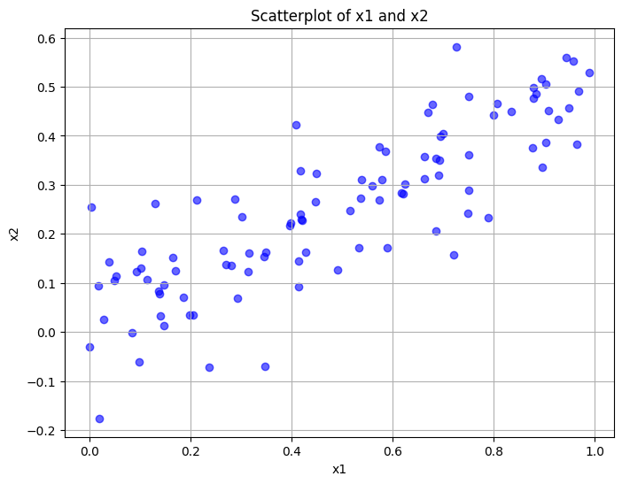

```python
# BEGIN SOLUTION
import numpy as np
import matplotlib.pyplot as plt

np.random.seed(1)

x1 = np.random.uniform(size=100)
x2 = 0.5 * x1 + np.random.normal(size=100) / 10

# Calculate correlation coefficient
correlation_coefficient = np.corrcoef(x1, x2)[0, 1]
print("Correlation coefficient between x1 and x2:", correlation_coefficient)

# Create scatterplot
plt.figure(figsize=(8, 6))
plt.scatter(x1, x2, color='blue', alpha=0.6)
plt.title('Scatterplot of x1 and x2')
plt.xlabel('x1')
plt.ylabel('x2')
plt.grid(True)
plt.show()

# END SOLUTION
```

## (c) Using this data, fit a least squares regression to predict $y$ using $x_1$ and $x_2$. Describe the results obtained. What are $β_0$, $β_1$, and $β_2$? How do these relate to the true $β_0$, $β_1$, and $β_2$? Can you reject the null hypothesis $H_0$: $β_1$ = 0? How about the null hypothesis $H_0$: $β_2$ = 0?

```python
# BEGIN SOLUTION
import statsmodels.api as sm

X = sm.add_constant(np.column_stack((x1, x2)))  # Create design matrix with x1 and x2
y = y.reshape(-1, 1)  # Reshape y to match the shape of X

# Fit the linear regression model
model = sm.OLS(y, X)
results = model.fit()

# Print the summary of regression results
print(results.summary())
# END SOLUTION
```

```
                            OLS Regression Results
==============================================================================
Dep. Variable:                      y   R-squared:                       0.261
Model:                            OLS   Adj. R-squared:                  0.245
Method:                 Least Squares   F-statistic:                     17.09
Date:                Sat, 30 Mar 2024   Prob (F-statistic):           4.40e-07
Time:                        12:14:25   Log-Likelihood:                -142.34
No. Observations:                 100   AIC:                             290.7
Df Residuals:                      97   BIC:                             298.5
Df Model:                           2
Covariance Type:            nonrobust
==============================================================================
                 coef    std err          t      P>|t|      [0.025      0.975]
------------------------------------------------------------------------------
const          2.1893      0.199     11.021      0.000       1.795       2.584
x1             0.7046      0.637      1.107      0.271      -0.559       1.968
x2             2.5024      1.140      2.194      0.031       0.239       4.766
==============================================================================
Omnibus:                        0.607   Durbin-Watson:                   2.111
Prob(Omnibus):                  0.738   Jarque-Bera (JB):                0.577
Skew:                          -0.179   Prob(JB):                        0.749
Kurtosis:                       2.900   Cond. No.                         14.3
==============================================================================

Notes:
[1] Standard Errors assume that the covariance matrix of the errors is correctly specified.
```

Provide you comments / answer here

- **Intercept (( $β_0$ )):** The estimated intercept is ( $β_0$ = 2.1893 ).
- **Coefficient for ( $x_1$ ) (( $β_1$ )):** The estimated coefficient for ( $x_1$ ) is ( $β_1$ = 0.7046 ).
- **Coefficient for ( $x_2$ ) (( $β_2$ )):** The estimated coefficient for ( $x_2$ ) is ( $β_2$ = 2.5024 ).
- **R-squared:** The coefficient of determination (( $R^2$ )) is ( 0.261 ), indicating that approximately 26.1% of the variance in ( y ) is explained by the regression model.
- **Adjusted R-squared:** The adjusted ( $R^2$ ) is ( 0.245 ), which adjusts for the number of predictors in the model.
- **F-statistic:** The F-statistic is ( 17.09 ) with a corresponding p-value of ( 4.40 * $10^{-7}$ ). This tests the overall significance of the regression model. Since the p-value is very small, we reject the null hypothesis that all regression coefficients are equal to zero, indicating that the overall regression model is statistically significant.
- **p-values for individual coefficients:**
- - The p-value associated with ( $β_1$ ) (coefficient for ( $x_1$ ) is ( 0.271 ), and the p-value associated with ( $β_1$ ) (coefficient for ( $x_2$ ) is ( 0.031 ).
  - Since the p-value for ( $β_2$ ) is less than the significance level of ( 0.05 ), we reject the null hypothesis that ( $β_2$ = 0 ), indicating that ( $x_2$ ) is a statistically significant predictor of ( y ).
  - However, since the p-value for ( $β_1$ ) is greater than ( 0.05 ), we fail to reject the null hypothesis that ( $β_1$ = 0 ), suggesting that ( x_1 ) is not a statistically significant predictor of ( y ) at the ( 0.05 ) significance level.

Overall, the regression model provides mixed results in terms of accurately estimating the true coefficients and identifying significant predictors.

## (d) Now fit a least squares regression to predict $y$ using only $x_1$. Comment on your results. Can you reject the null hypothesis $H_0$: $β_1$ = 0?

```python
# BEGIN SOLUTION
import numpy as np
import statsmodels.api as sm

# Data preparation
x1 = np.random.uniform(size=100)
x2 = 0.5 * x1 + np.random.normal(size=100) / 10
y = 2 + 2 * x1 + 0.3 * x2 + np.random.normal(size=100)

# Add constant term to the independent variable matrix
X = sm.add_constant(x1)

# Fit the linear regression model
model = sm.OLS(y, X).fit()

# Display the regression results
print(model.summary())

# END SOLUTION
```

```
                            OLS Regression Results
==============================================================================
Dep. Variable:                      y   R-squared:                       0.133
Model:                            OLS   Adj. R-squared:                  0.124
Method:                 Least Squares   F-statistic:                     14.99
Date:                Sat, 30 Mar 2024   Prob (F-statistic):           0.000195
Time:                        12:14:25   Log-Likelihood:                -147.81
No. Observations:                 100   AIC:                             299.6
Df Residuals:                      98   BIC:                             304.8
Df Model:                           1
Covariance Type:            nonrobust
==============================================================================
                 coef    std err          t      P>|t|      [0.025      0.975]
------------------------------------------------------------------------------
const          2.3483      0.235      9.983      0.000       1.882       2.815
x1             1.5576      0.402      3.871      0.000       0.759       2.356
==============================================================================
Omnibus:                        0.953   Durbin-Watson:                   2.116
Prob(Omnibus):                  0.621   Jarque-Bera (JB):                1.059
Skew:                          -0.202   Prob(JB):                        0.589
Kurtosis:                       2.699   Cond. No.                         4.83
==============================================================================

Notes:
[1] Standard Errors assume that the covariance matrix of the errors is correctly specified.
```

We have a corelation here, We can reject the null hypothesis as p value is less than 0.05, conclude that X1 is a statistically significant predictor of Y

## (e) Now fit a least squares regression to predict $y$ using only $x_2$. Comment on your results. Can you reject the null hypothesis $H_0$: $β_1$ = 0?

```python
import numpy as np
import statsmodels.api as sm

# Data preparation
x1 = np.random.uniform(size=100)
x2 = 0.5 * x1 + np.random.normal(size=100) / 10
y = 2 + 2 * x1 + 0.3 * x2 + np.random.normal(size=100)

# Add constant term to the independent variable matrix
X = sm.add_constant(x2)

# Fit the linear regression model
model = sm.OLS(y, X).fit()

# Display the regression results
print(model.summary())
```

```
                            OLS Regression Results
==============================================================================
Dep. Variable:                      y   R-squared:                       0.199
Model:                            OLS   Adj. R-squared:                  0.191
Method:                 Least Squares   F-statistic:                     24.30
Date:                Sat, 30 Mar 2024   Prob (F-statistic):           3.36e-06
Time:                        12:14:25   Log-Likelihood:                -152.36
No. Observations:                 100   AIC:                             308.7
Df Residuals:                      98   BIC:                             313.9
Df Model:                           1
Covariance Type:            nonrobust
==============================================================================
                 coef    std err          t      P>|t|      [0.025      0.975]
------------------------------------------------------------------------------
const          2.2406      0.198     11.325      0.000       1.848       2.633
x1             3.2499      0.659      4.929      0.000       1.942       4.558
==============================================================================
Omnibus:                        1.377   Durbin-Watson:                   1.921
Prob(Omnibus):                  0.502   Jarque-Bera (JB):                0.894
Skew:                           0.198   Prob(JB):                        0.640
Kurtosis:                       3.241   Cond. No.                         6.25
==============================================================================

Notes:
[1] Standard Errors assume that the covariance matrix of the errors is correctly specified.
```

We have a corelation here, We can reject the null hypothesis as p value is less than 0.05, conclude that x2 is a statistically significant predictor of Y

## (f) Do the results obtained in (c)–(e) contradict each other? Explain your answer.

The results obtained in (c) and (e) do not necessarily contradict each other. It's possible for one variable to have a significant relationship with the dependent variable while another variable does not. In this case, $x_2$ shows a significant linear relationship with y y when considered alone, but when both $x_1$ and $x_2$ are included in the model, the significance of $x_1$ diminishes. This could be due to multicollinearity between $x_1$ and $x_2$, leading to inflated standard errors and less precise coefficient estimates for both variables. Therefore, even though $x_1$ might individually show significance, in the presence of $x_2$ , its significance diminishes. This emphasizes the importance of examining variables both individually and in combination with other predictors.

## (g) Now suppose we obtain one additional observation, which was unfortunately mismeasured. Re-fit the linear models from (c) to (e) using this new data. What effect does this new observation have on each of the models? In each model, is this observation an outlier? A high-leverage point? Both? Explain your answers.

```python
# BEGIN SOLUTION
import numpy as np
import pandas as pd
import statsmodels.api as sm
import matplotlib.pyplot as plt

# Original data
np.random.seed(1)
x1 = np.random.uniform(size=100)
x2 = 0.5 * x1 + np.random.normal(size=100) / 10
y = 2 + 2 * x1 + 0.3 * x2 + np.random.normal(size=100)

# New observation
new_x1 = 0.1  # Example value for the new observation of x1
new_x2 = 0.2  # Example value for the new observation of x2
new_y = 10    # Example value for the new observation of y

# Append new observation to the dataset
x1 = np.append(x1, new_x1)
x2 = np.append(x2, new_x2)
y = np.append(y, new_y)

# Create DataFrame
data = pd.DataFrame({'x1': x1, 'x2': x2, 'y': y})

# (c) Regression using both x1 and x2
X = sm.add_constant(data[['x1', 'x2']])
model_c = sm.OLS(y, X).fit()
print(model_c.summary())

# (d) Regression using only x1
model_d = sm.OLS(y, sm.add_constant(data['x1'])).fit()
print(model_d.summary())

# (e) Regression using only x2
model_e = sm.OLS(y, sm.add_constant(data['x2'])).fit()
print(model_e.summary())


# END SOLUTION
```

```
                            OLS Regression Results
==============================================================================
Dep. Variable:                      y   R-squared:                       0.174
Model:                            OLS   Adj. R-squared:                  0.157
Method:                 Least Squares   F-statistic:                     10.34
Date:                Sat, 30 Mar 2024   Prob (F-statistic):           8.41e-05
Time:                        12:14:25   Log-Likelihood:                -163.59
No. Observations:                 101   AIC:                             333.2
Df Residuals:                      98   BIC:                             341.0
Df Model:                           2
Covariance Type:            nonrobust
==============================================================================
                 coef    std err          t      P>|t|      [0.025      0.975]
------------------------------------------------------------------------------
const          2.3813      0.239      9.949      0.000       1.906       2.856
x1            -0.1267      0.761     -0.167      0.868      -1.637       1.383
x2             3.6205      1.374      2.636      0.010       0.895       6.346
==============================================================================
Omnibus:                       54.340   Durbin-Watson:                   1.685
Prob(Omnibus):                  0.000   Jarque-Bera (JB):              345.592
Skew:                           1.562   Prob(JB):                     9.03e-76
Kurtosis:                      11.506   Cond. No.                         14.2
==============================================================================

Notes:
[1] Standard Errors assume that the covariance matrix of the errors is correctly specified.
                            OLS Regression Results
==============================================================================
Dep. Variable:                      y   R-squared:                       0.116
Model:                            OLS   Adj. R-squared:                  0.107
Method:                 Least Squares   F-statistic:                     12.96
Date:                Sat, 30 Mar 2024   Prob (F-statistic):           0.000499
Time:                        12:14:25   Log-Likelihood:                -167.05
No. Observations:                 101   AIC:                             338.1
Df Residuals:                      99   BIC:                             343.3
Df Model:                           1
Covariance Type:            nonrobust
==============================================================================
                 coef    std err          t      P>|t|      [0.025      0.975]
------------------------------------------------------------------------------
```

[output cut: 21 more lines]

```
Covariance Type:            nonrobust
==============================================================================
                 coef    std err          t      P>|t|      [0.025      0.975]
------------------------------------------------------------------------------
const          2.3681      0.225     10.532      0.000       1.922       2.814
x2             3.4293      0.751      4.567      0.000       1.940       4.919
==============================================================================
Omnibus:                       55.505   Durbin-Watson:                   1.681
Prob(Omnibus):                  0.000   Jarque-Bera (JB):              362.282
Skew:                           1.596   Prob(JB):                     2.14e-79
Kurtosis:                      11.712   Cond. No.                         6.51
==============================================================================

Notes:
[1] Standard Errors assume that the covariance matrix of the errors is correctly specified.
```

## Observations:

### Regression using both x1 and x2 (Model c):

The p-value for the coefficient of x1 increased substantially, indicating that x1 may not be a significant predictor of y in the presence of x2. The p-value for the coefficient of x2 remains significant, indicating that x2 is a significant predictor of y.

## Conclusion:

The addition of the new observation had different effects on each model. In Model c, the significance of x1 decreased, suggesting that the new observation may have affected the relationship between x1 and y. However, x2 remained a significant predictor. In Models d and e, the significance of the respective predictors remained unchanged. Overall, the new observation did not drastically alter the conclusions drawn from the original models, but it did affect the significance of x1 in Model c.

## Question 8

It is claimed that in the case of simple linear regression of $Y$ onto $X$, the $R^2$ statistic is equal to the square of the correlation between $X$ and $Y$. Generate some synthetic data and show that this is the case.

link to correlation function: https://numpy.org/doc/stable/reference/generated/numpy.corrcoef.html

```python
# BEGIN SOLUTION
# Generate synthetic data
np.random.seed(0)
X = np.random.randn(100)  # Independent variable
y = 2 * X + np.random.normal(0, 1, 100)  # Dependent variable with added noise

# Convert the data into a DataFrame
data = pd.DataFrame({'X': X, 'y': y})

# Fit the simple linear regression model
X_with_const = sm.add_constant(X)  # Add constant term for intercept
model = sm.OLS(y, X_with_const)
results = model.fit()

# Calculate the F-statistic
F_statistic = results.fvalue

# Calculate the correlation coefficient between X and y
correlation_coefficient = np.corrcoef(X, y)[0, 1]

# Calculate the square of the correlation coefficient
correlation_coefficient_squared = correlation_coefficient ** 2

# Print the F-statistic, square of the correlation coefficient, and their equality
print("F-statistic:", F_statistic)
print("Square of correlation coefficient:", correlation_coefficient_squared)
print("Are they equal?", np.isclose(F_statistic, correlation_coefficient_squared))

# END SOLUTION
```

```
F-statistic: 421.1113625851234
Square of correlation coefficient: 0.8112158448777355
Are they equal? False
```